# Data Preprocessing

```r
data <- read.csv("D:/FILE DHEA/Kuliah/KMMI/TUGAS/studentperformances.csv")
head(data)
```

```
##   gender    race parental_level_of_education        lunch
## 1 female group B           bachelor's degree     standard
## 2 female group C                some college     standard
## 3 female group B             master's degree     standard
## 4   male group A          associate's degree free/reduced
## 5   male group C                some college     standard
## 6 female group B          associate's degree     standard
##   test_preparation_course math_score reading_score writing_score average_score
## 1                    none         72            72            74      72.66667
## 2               completed         69            90            88      82.33333
## 3                    none         90            95            93      92.66667
## 4                    none         47            57            44      49.33333
## 5                    none         76            78            75      76.33333
## 6                    none         71            83            78      77.33333
```

## 1. Pengecekan Missing Value

```r
paste("Jumlah missing value =",sum(is.na(data)))
```

```
## [1] "Jumlah missing value = 0"
```

Tidak ditemukan adanya NA pada data, sehingga data aman dari missing value.

## 2. Pengecekan Duplikasi Data

```r
duplicated(data)
```

[output not shown]

[output cut: 69 more lines]

Tidak ditemukan adanya duplikasi pada data, sehingga data aman dari duplikasi.

## 3. Pengecekan Outlier

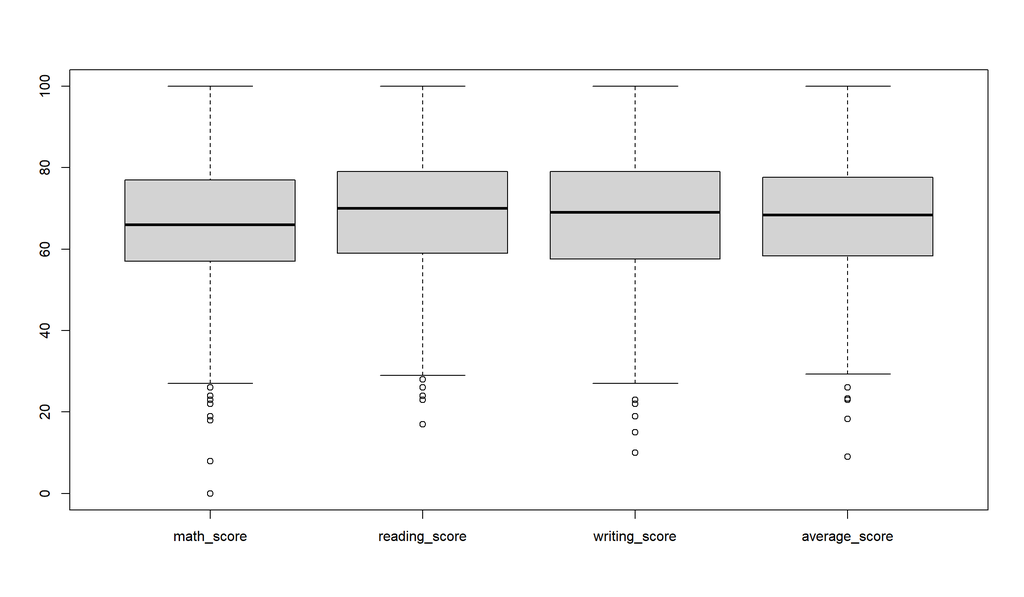

```r
data_num <- data[c(6:9)]
boxplot(data_num)
```

Karena terdapat outlier pada atribut numerik data, maka outlier perlu dihilangkan

### Cek baris outlier

Sebelum dilakukannya data cleaning, dilakukan proses identifikasi data yang menyebabkan adanya outlier

```r
# Variabel Math Score
boxplot.stats(data$math_score)$out
```

```
## [1] 18  0 22 24 26 19 23  8
```

```r
out <- boxplot.stats(data$math_score)$out
out_ind <- which(data$math_score %in% c(out))
out_ind
```

```
## [1]  18  60 146 339 467 788 843 981
```

Dari hasil pengecekan data outlier, pada variabel math_score diketahui terdapat 8 data penyebab outlier yaitu pada baris ke 18, 60, 146, 339, 467, 788, 843, dan 981.

```r
# Variabel Reading Score
boxplot.stats(data$reading_score)$out
```

```
## [1] 17 26 28 23 24 24
```

```r
out <- boxplot.stats(data$reading_score)$out
out_ind <- which(data$reading_score %in% c(out))
out_ind
```

```
## [1]  60  77 212 328 597 981
```

Pada variabel reading_score, terdapat 6 data penyebab outlier diantaranya pada baris ke 60, 77, 212, 328, 597, dan 981.

```r
# Variabel Writing Score
boxplot.stats(data$writing_score)$out
```

```
## [1] 10 22 19 15 23
```

```r
out <- boxplot.stats(data$writing_score)$out
out_ind <- which(data$writing_score %in% c(out))
out_ind
```

```
## [1]  60  77 328 597 981
```

Pada variabel writing_score, terdapat 5 data penyebab outlier diantaranya pada baris ke 60, 77, 328, 597, dan 981.

```r
# Variabel Average Score
boxplot.stats(data$average_score)$out
```

```
## [1] 26.00000  9.00000 26.00000 23.33333 23.00000 18.33333
```

```r
out <- boxplot.stats(data$average_score)$out
out_ind <- which(data$average_score %in% c(out))
out_ind
```

```
## [1]  18  60  77 328 597 981
```

Pada variabel average_score, diketahui terdapat 6 data penyebab outlier yaitu pada baris ke 18, 60, 77, 328, 597, dan 981.

Dari hasil cek outlier keempat variabel, diketahui jumlah data outlier tidak berjumlah besar sehingga dapat dengan mudah dilakukan penghapusan baris. Baris yang terdapat outlier yaitu berjumlah 12 diantaranya pada baris ke 18, 60, 77, 146, 212, 328, 339, 467, 597, 788, 843, dan 981.

### Penghapusan outlier pertama

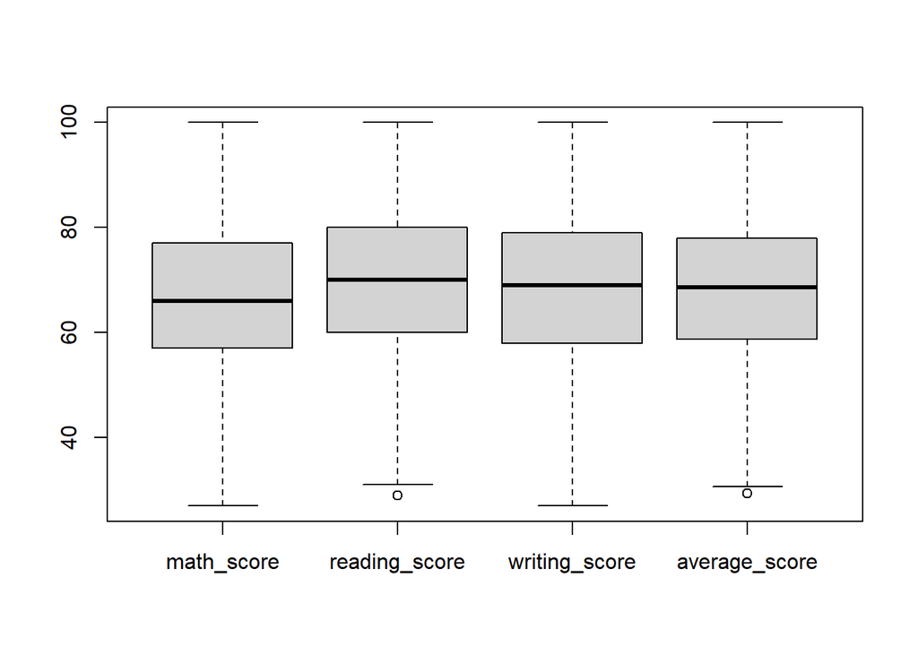

```r
newdata1 <- data[-c(18, 60, 77, 146, 212, 328, 339, 467, 597, 788, 843, 981),]
boxplot(newdata1[c(6:9)])
```

Dari hasil boxplot setelah dilakukannya proses penghapusan outlier pertama, ternyata masih terdapat outlier pada variabel reading_Score dan averaga_score sehingga perlu dilakukan pengecekan dan data cleaning kedua untuk benar-benar membersihkan outlier pada dataset

### Cek outlier pada variabel reading_score dan average_Score

```r
boxplot.stats(newdata1$reading_score)$out
```

```
## [1] 29 29
```

```r
out <- boxplot.stats(newdata1$reading_score)$out
out_ind <- which(newdata1$reading_score %in% c(out))
out_ind
```

```
## [1] 593 886
```

Dari hasil output diketahui terdapat 2 data penyebab outlier pada variabel reading_score yaitu baris ke-593 dan baris ke-886.

```r
boxplot.stats(newdata1$average_score)$out
```

```
## [1] 29.33333
```

```r
out <- boxplot.stats(newdata1$average_score)$out
out_ind <- which(newdata1$average_score %in% c(out))
out_ind
```

```
## [1] 593
```

Dari hasil output pada cek data outlier variabel average_score, diketahui terdapat 1 data penyebab outlier yaitu pada varis ke 593.

Dari kedua variabel yang masih terdapat outlier setelah dilakukannya proses data cleaning pertama, diperoleh bahwa terdapat 2 baris penyebab outlier yaitu baris ke-593 dan baris ke-886. Oleh karena data outlier berjumlah sedikit, dapat dilakukan proses penghapusan baris kedua.

#Penghapusan outlier kedua

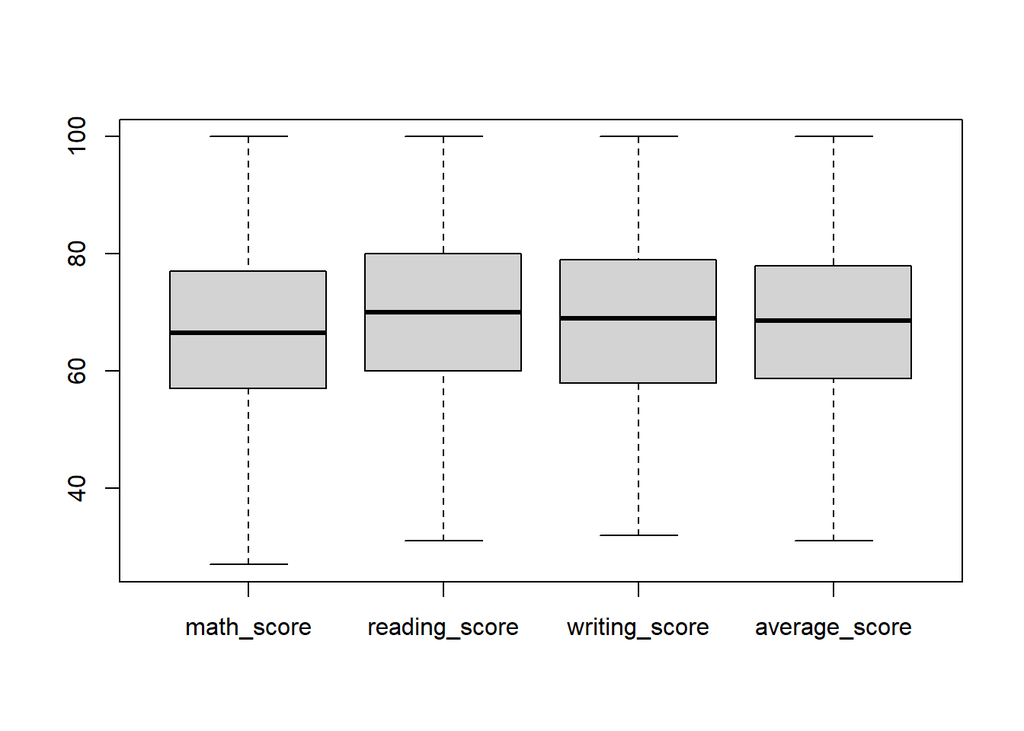

```r
newdata2 <- newdata1[-c(593, 886),]
boxplot(newdata2[c(6:9)])
```

Dari gambar boxplot setelah dilakukan proses penghapusan baris kedua kalinya, dapat diketahui sudah tidak ada outlier pada data. Hal tersebut ditunjukkan dengan tidak ada titik-titik diluar kotak.

## 4. Data Transformation

```r
newdata2[9]<-round(newdata2[9],2)
head(newdata2)
```

```
##   gender    race parental_level_of_education        lunch
## 1 female group B           bachelor's degree     standard
## 2 female group C                some college     standard
## 3 female group B             master's degree     standard
## 4   male group A          associate's degree free/reduced
## 5   male group C                some college     standard
## 6 female group B          associate's degree     standard
##   test_preparation_course math_score reading_score writing_score average_score
## 1                    none         72            72            74         72.67
## 2               completed         69            90            88         82.33
## 3                    none         90            95            93         92.67
## 4                    none         47            57            44         49.33
## 5                    none         76            78            75         76.33
## 6                    none         71            83            78         77.33
```

Atribut Average Score dibulatkan 2 bilangan di belakang koma agar seragam dengan atribut lainnya.

```r
summary(newdata2)
```

```
##     gender              race           parental_level_of_education
##  Length:986         Length:986         Length:986
##  Class :character   Class :character   Class :character
##  Mode  :character   Mode  :character   Mode  :character
##
##
##
##     lunch           test_preparation_course   math_score     reading_score
##  Length:986         Length:986              Min.   : 27.00   Min.   : 31.00
##  Class :character   Class :character        1st Qu.: 57.00   1st Qu.: 60.00
##  Mode  :character   Mode  :character        Median : 66.50   Median : 70.00
##                                             Mean   : 66.69   Mean   : 69.72
##                                             3rd Qu.: 77.00   3rd Qu.: 80.00
##                                             Max.   :100.00   Max.   :100.00
##  writing_score    average_score
##  Min.   : 32.00   Min.   : 31.00
##  1st Qu.: 58.00   1st Qu.: 58.67
##  Median : 69.00   Median : 68.67
##  Mean   : 68.65   Mean   : 68.36
##  3rd Qu.: 79.00   3rd Qu.: 78.00
##  Max.   :100.00   Max.   :100.00
```

Karena dataset sudah dalam bentuk yang sesuai maka transformasi data tidak perlu dilanjutkan.

## Results

###Histogram dan Density

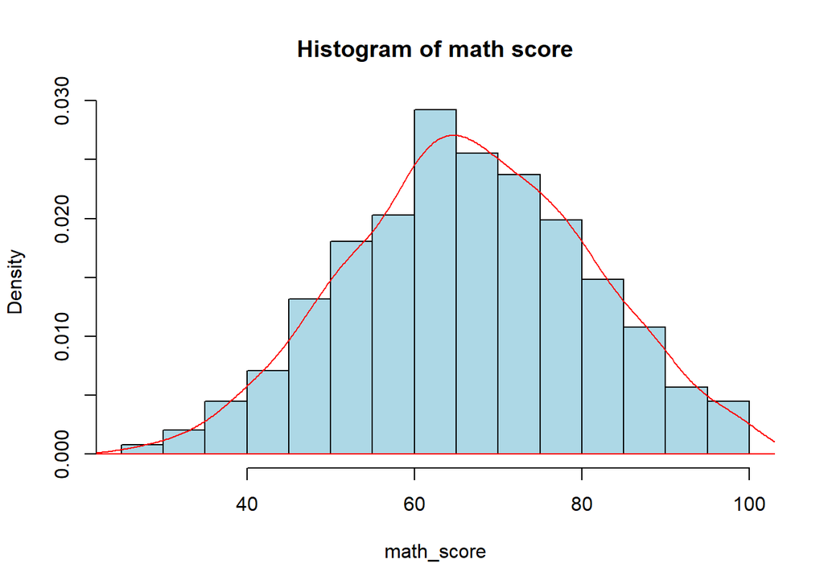

```r
dens <- density(newdata2$math_score)
hist(newdata2$math_score, freq = FALSE,
     main = "Histogram of math score",
     xlab = "math_score",
     col = "lightblue")
polygon(dens, border = "red")
```

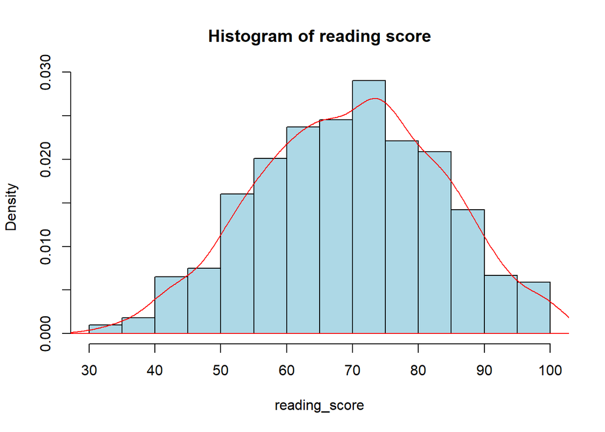

```r
dens <- density(newdata2$reading_score)
hist(newdata2$reading_score, freq = FALSE,
     main = "Histogram of reading score",
     xlab = "reading_score",
     col = "lightblue")
polygon(dens, border = "red")
```

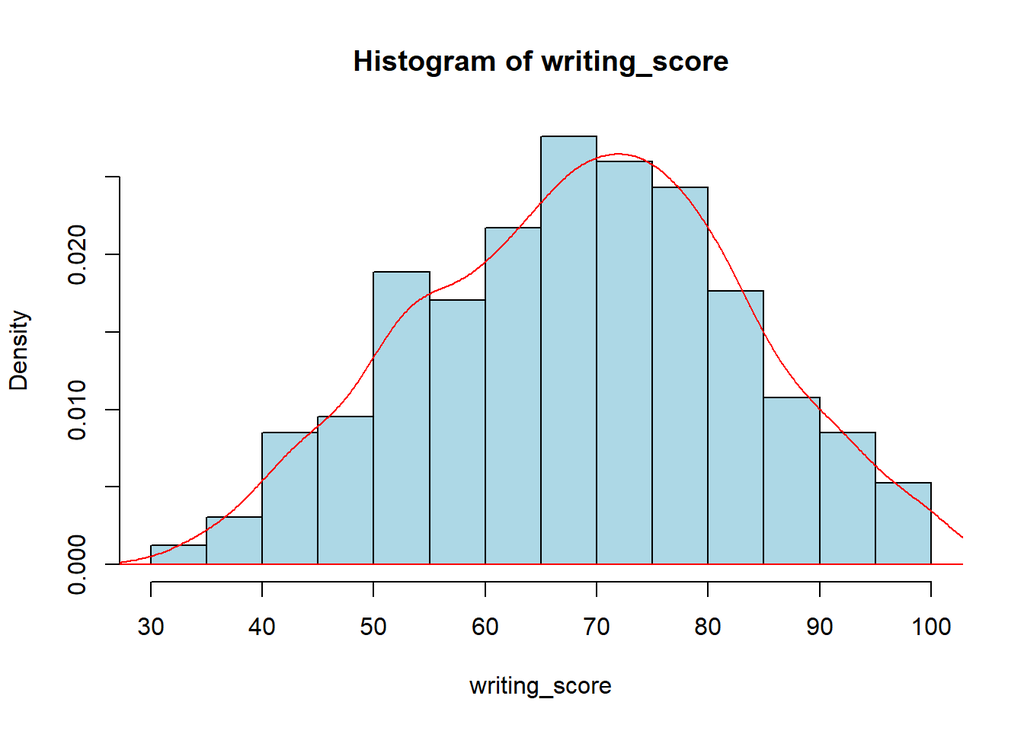

```r
dens <- density(newdata2$writing_score)
hist(newdata2$writing_score, freq = FALSE,
     main = "Histogram of writing_score",
     xlab = "writing_score",
     col = "lightblue")
polygon(dens, border = "red")
```

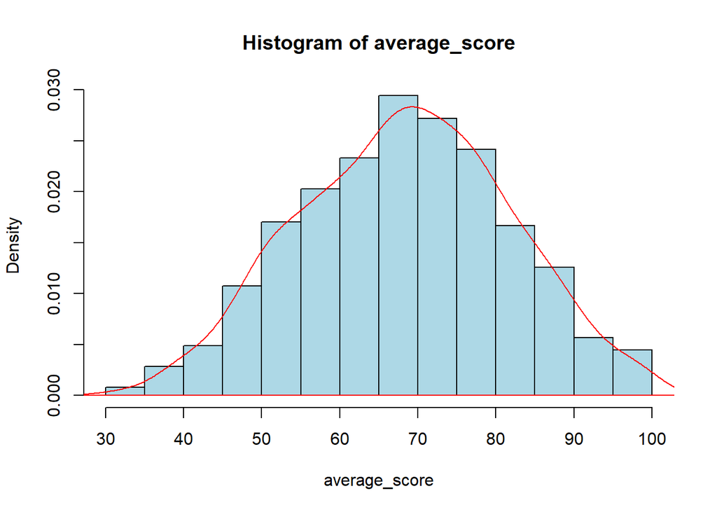

```r
dens <- density(newdata2$average_score)
hist(newdata2$average_score, freq = FALSE,
     main = "Histogram of average_score",
     xlab = "average_score",
     col = "lightblue")
polygon(dens, border = "red")
```

Dari hasil output histogram keempat variabel, diketahui kurva berbentuk garis lengkung yang halus dan berbentuk seperti lonceng (Bell Shaped), simetris terhadap rata-rata (mean), kedua ekor/ujungnya semakin mendekati sumbunya tetapi tidak pernah memotong. Sehingga dapat dikatakan newdata2 (data setelah dilakukan preprocessing) berdistribusi normal.

```r
#membandingkan data sebelum dan sesudah preprocessing
head(data)
```

```
##   gender    race parental_level_of_education        lunch
## 1 female group B           bachelor's degree     standard
## 2 female group C                some college     standard
## 3 female group B             master's degree     standard
## 4   male group A          associate's degree free/reduced
## 5   male group C                some college     standard
## 6 female group B          associate's degree     standard
##   test_preparation_course math_score reading_score writing_score average_score
## 1                    none         72            72            74      72.66667
## 2               completed         69            90            88      82.33333
## 3                    none         90            95            93      92.66667
## 4                    none         47            57            44      49.33333
## 5                    none         76            78            75      76.33333
## 6                    none         71            83            78      77.33333
```

```r
head(newdata2)
```

```
##   gender    race parental_level_of_education        lunch
## 1 female group B           bachelor's degree     standard
## 2 female group C                some college     standard
## 3 female group B             master's degree     standard
## 4   male group A          associate's degree free/reduced
## 5   male group C                some college     standard
## 6 female group B          associate's degree     standard
##   test_preparation_course math_score reading_score writing_score average_score
## 1                    none         72            72            74         72.67
## 2               completed         69            90            88         82.33
## 3                    none         90            95            93         92.67
## 4                    none         47            57            44         49.33
## 5                    none         76            78            75         76.33
## 6                    none         71            83            78         77.33
```

```r
summary(data)
```

```
##     gender              race           parental_level_of_education
##  Length:1000        Length:1000        Length:1000
##  Class :character   Class :character   Class :character
##  Mode  :character   Mode  :character   Mode  :character
##
##
##
##     lunch           test_preparation_course   math_score     reading_score
##  Length:1000        Length:1000             Min.   :  0.00   Min.   : 17.00
##  Class :character   Class :character        1st Qu.: 57.00   1st Qu.: 59.00
##  Mode  :character   Mode  :character        Median : 66.00   Median : 70.00
##                                             Mean   : 66.09   Mean   : 69.17
##                                             3rd Qu.: 77.00   3rd Qu.: 79.00
##                                             Max.   :100.00   Max.   :100.00
##  writing_score    average_score
##  Min.   : 10.00   Min.   :  9.00
##  1st Qu.: 57.75   1st Qu.: 58.33
##  Median : 69.00   Median : 68.33
##  Mean   : 68.05   Mean   : 67.77
##  3rd Qu.: 79.00   3rd Qu.: 77.67
##  Max.   :100.00   Max.   :100.00
```

```r
summary(newdata2)
```

```
##     gender              race           parental_level_of_education
##  Length:986         Length:986         Length:986
##  Class :character   Class :character   Class :character
##  Mode  :character   Mode  :character   Mode  :character
##
##
##
##     lunch           test_preparation_course   math_score     reading_score
##  Length:986         Length:986              Min.   : 27.00   Min.   : 31.00
##  Class :character   Class :character        1st Qu.: 57.00   1st Qu.: 60.00
##  Mode  :character   Mode  :character        Median : 66.50   Median : 70.00
##                                             Mean   : 66.69   Mean   : 69.72
##                                             3rd Qu.: 77.00   3rd Qu.: 80.00
##                                             Max.   :100.00   Max.   :100.00
##  writing_score    average_score
##  Min.   : 32.00   Min.   : 31.00
##  1st Qu.: 58.00   1st Qu.: 58.67
##  Median : 69.00   Median : 68.67
##  Mean   : 68.65   Mean   : 68.36
##  3rd Qu.: 79.00   3rd Qu.: 78.00
##  Max.   :100.00   Max.   :100.00
```

## Export Dataset

```r
write.csv(newdata2, "D:/dataset/dataUAS.csv", row.names = FALSE)
```